# HW4_21500268_ParkSeongchan

박스플랏에서 볼 수 있듯, Ir(비)이나 Is(눈)이 아예 오지 않는 경우에 월등히 미세먼지 수치가 높은 관측들을 자주 볼 수 있었다.

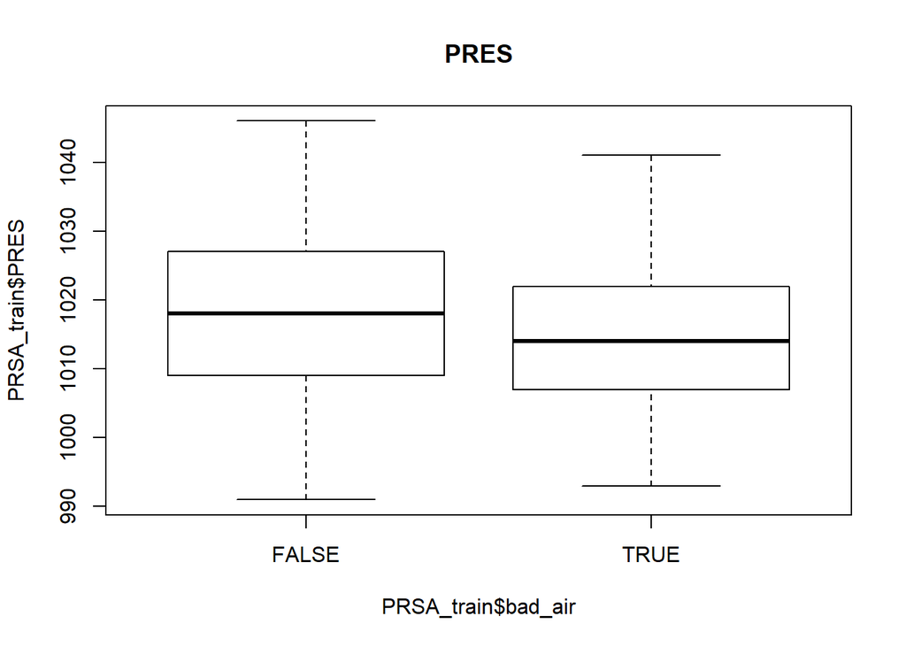

```r
boxplot(PRSA_train$PRES ~ PRSA_train$bad_air, main = "PRES")
```

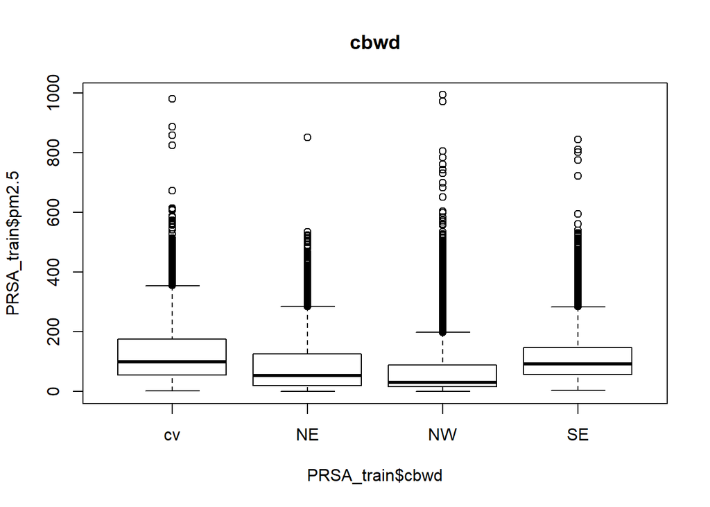

```r
boxplot(PRSA_train$pm2.5 ~ PRSA_train$cbwd, main = "cbwd")
```

마지막으로는 PRES와 cbwd 변수를 통해서 미세먼지 수치를 확인했다.

박스플랏에서 볼 수 있듯, PRES(기압)가 높을 때보다 낮을 때 미세먼지 농도가 평균적으로 더 심했다. 하지만 그 차이가 그렇게 크지는 않음도 확인할 수 있다.

cbwd(풍향)에 대해서는 outlier들이 많이 있긴 하지만, 전반적으로 cv와 SE인 경우가 NE와 NW인 경우보다 높았던 것을 확인할 수 있다.

# DEWP와 TEMP 변수 이용

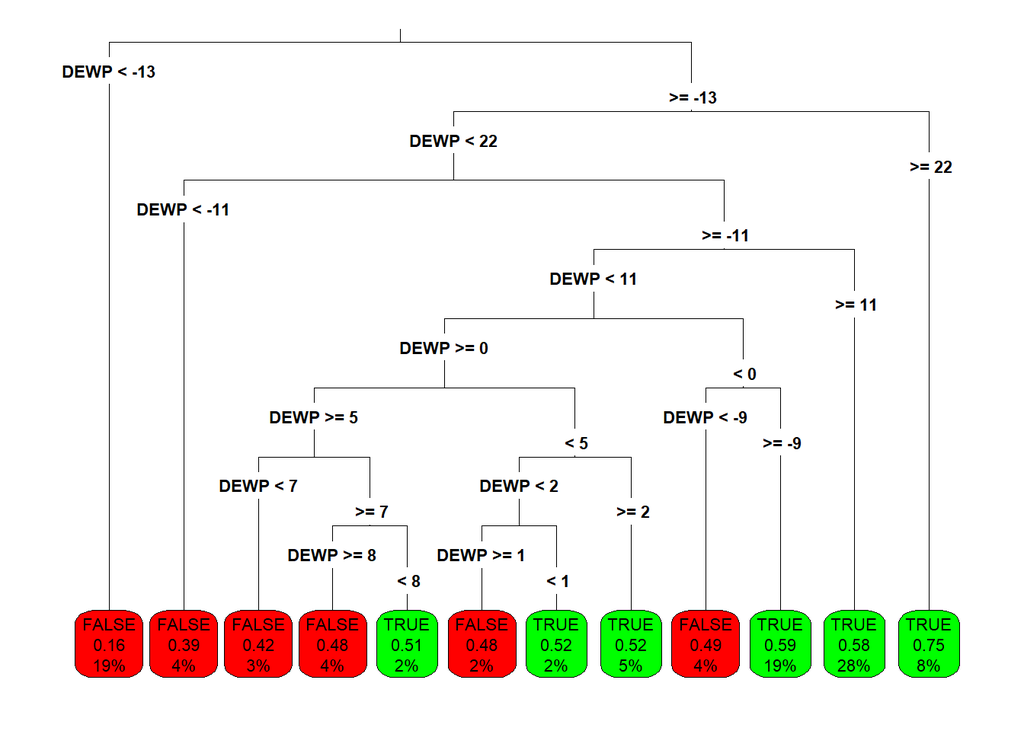

```r
par(mfrow = c(1, 1))
PRSA_model <- rpart(bad_air ~ DEWP, data = PRSA_train, method = 'class',
                    control = rpart.control(cp = 0))
rpart.plot(PRSA_model, type = 3, box.palette = c('red', 'green'),
           fallen.leaves = TRUE)
```

```r
PRSA_train$pred.DEWP <- predict(PRSA_model, PRSA_train, type = 'class')
table(PRSA_train$bad_air, PRSA_train$pred.DEWP)
```

```
##
##         FALSE  TRUE
##   FALSE  8521  8490
##   TRUE   3609 12476
```

```r
mean(PRSA_train$bad_air == PRSA_train$pred.DEWP)
```

```
## [1] 0.6344271
```

앞서 박스플랏을 통해 보았던 변수들을 통해 예측 모델을 만들려고 한다.

가장 먼저 DEWP(이슬점) 변수에서는 전반적으로 이 값이 높을수록 미세먼지 농도가 좋지 않았음을 볼 수 있었다. 이를 예측 변수로 사용하여 결과를 보니 약 63%가 나왔다.

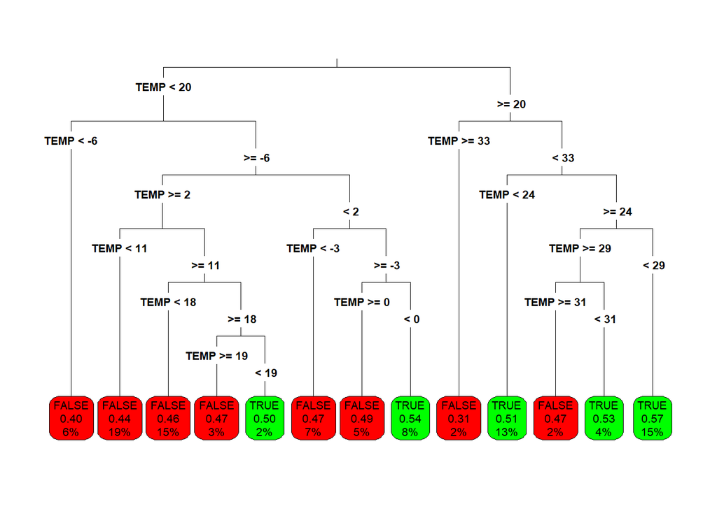

```r
PRSA_model <- rpart(bad_air ~ TEMP, data = PRSA_train, method = 'class',
                    control = rpart.control(cp = 0))
rpart.plot(PRSA_model, type = 3, box.palette = c('red', 'green'),
           fallen.leaves = TRUE)
```

```r
PRSA_train$pred.TEMP <- predict(PRSA_model, PRSA_train, type = 'class')
table(PRSA_train$bad_air, PRSA_train$pred.TEMP)
```

```
##
##         FALSE  TRUE
##   FALSE 10634  6377
##   TRUE   8590  7495
```

```r
mean(PRSA_train$bad_air == PRSA_train$pred.TEMP)
```

```
## [1] 0.5477701
```

다음으로는 TEMP(온도) 변수를 통해 값을 확인해보니 약 54%가 나왔다. 앞선 박스플랏 안에서도 그 차이가 그렇게 크지 않았던 것으로 보아 TEMP 변수 단독으로는 좋은 성능을 기대하는 것을 어려울 것으로 생각된다.

[figure not shown]

```r
PRSA_model <- rpart(bad_air ~ DEWP + TEMP, data = PRSA_train, method = 'class',
                    control = rpart.control(cp = 0))
rpart.plot(PRSA_model, type = 3, box.palette = c('red', 'green'),
           fallen.leaves = TRUE)
```

```r
PRSA_train$pred.DEWP.TEMP <- predict(PRSA_model, PRSA_train, type = 'class')
table(PRSA_train$bad_air, PRSA_train$pred.DEWP.TEMP)
```

```
##
##         FALSE  TRUE
##   FALSE 11269  5742
##   TRUE   3175 12910
```

```r
mean(PRSA_train$bad_air == PRSA_train$pred.DEWP.TEMP)
```

```
## [1] 0.7305717
```

마지막으로는 DEWP와 TEMP 두 가지 변수를 모두 사용했다. 이슬점과 온도에 따른 미세먼지 수치를 예측하는 모델에서는 약 73% 정도가 나왔고, 확실히 단일 변수들보다는 다양한 변수들을 통해 그 수치가 높아지는 것을 확인할 수 있었다. 또한 이슬점과 온도라는 단 2개의 변수를 통해 70% 이상의 예측도를 보인 것으로 보아 이 변수들이 꽤 유의미한 변수들이라고 생각해볼 수 있었다.

# Ir과 Is 변수 이용

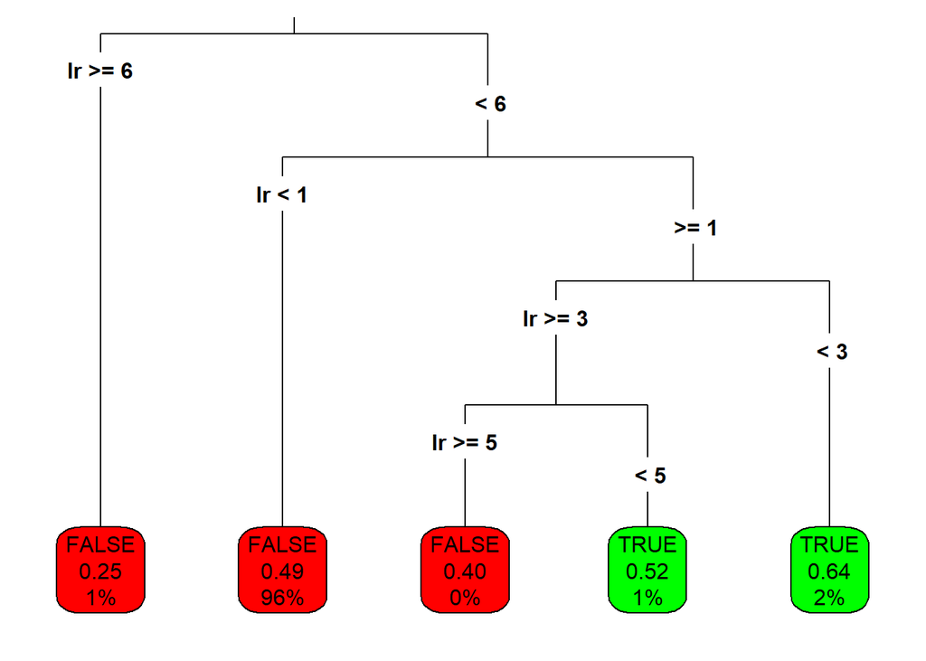

```r
PRSA_model <- rpart(bad_air ~ Ir, data = PRSA_train, method = 'class',
                    control = rpart.control(cp = 0))
rpart.plot(PRSA_model, type = 3, box.palette = c('red', 'green'),
           fallen.leaves = TRUE)
```

```r
PRSA_train$pred.Ir <- predict(PRSA_model, PRSA_train, type = 'class')
table(PRSA_train$bad_air, PRSA_train$pred.Ir)
```

```
##
##         FALSE  TRUE
##   FALSE 16631   380
##   TRUE  15511   574
```

```r
mean(PRSA_train$bad_air == PRSA_train$pred.Ir)
```

```
## [1] 0.5198513
```

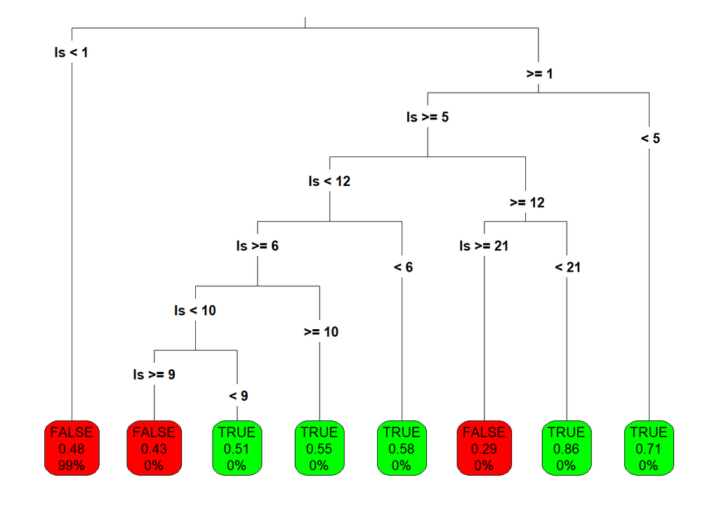

```r
PRSA_model <- rpart(bad_air ~ Is, data = PRSA_train, method = 'class',
                    control = rpart.control(cp = 0))
rpart.plot(PRSA_model, type = 3, box.palette = c('red', 'green'),
           fallen.leaves = TRUE)
```

```r
PRSA_train$pred.Is <- predict(PRSA_model, PRSA_train, type = 'class')
table(PRSA_train$bad_air, PRSA_train$pred.Is)
```

```
##
##         FALSE  TRUE
##   FALSE 16907   104
##   TRUE  15879   206
```

```r
mean(PRSA_train$bad_air == PRSA_train$pred.Is)
```

```
## [1] 0.5170715
```

다음으로는 Ir과 Is 변수를 이용해서 예측 모델을 만들어서 확인해보려고 한다.

Ir(비)과 Is(눈) 변수 모두 0일때, 미세먼지의 수치가 높았던 것을 위의 박스플랏을 통해 확인할 수 있었는데, 이 값이 너무 많다보니 사실상 이 변수들에서는 예측도가 그렇게 높지 않았다. Ir과 Is 모두에서 약 52% 정도의 수치를 보였다.

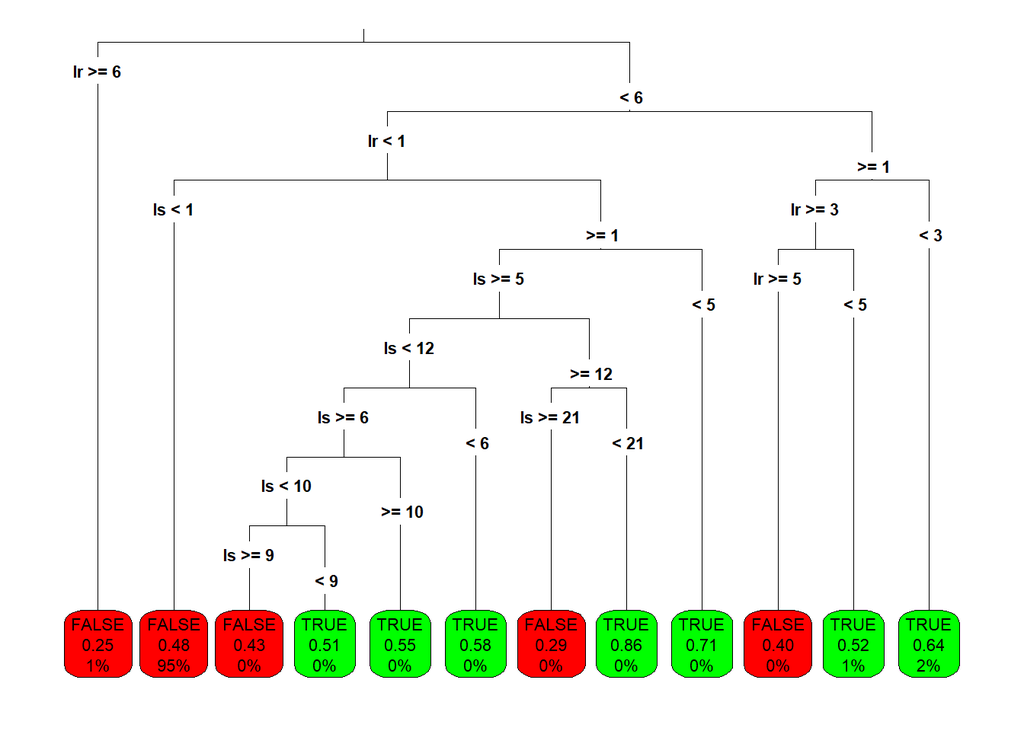

```r
PRSA_model <- rpart(bad_air ~ Ir + Is, data = PRSA_train, method = 'class',
                    control = rpart.control(cp = 0))
rpart.plot(PRSA_model, type = 3, box.palette = c('red', 'green'),
           fallen.leaves = TRUE)
```

```r
PRSA_train$pred.Ir.Is <- predict(PRSA_model, PRSA_train, type = 'class')
table(PRSA_train$bad_air, PRSA_train$pred.Ir.Is)
```

```
##
##         FALSE  TRUE
##   FALSE 16527   484
##   TRUE  15305   780
```

```r
mean(PRSA_train$bad_air == PRSA_train$pred.Ir.Is)
```

```
## [1] 0.5229333
```

또한 Ir과 Is 변수를 모두 사용한 결과에서도 위의 값보다 조금 더 개선된 52.3% 정도의 수치를 보였다. 이를 통해 결국 미세먼지를 예측하기 위해서 눈과 비의 변수들로만 보아서는 정확히 판단하는 것이 어렵다고 판단된다.

# PRES와 cbwd, Iws를 이용

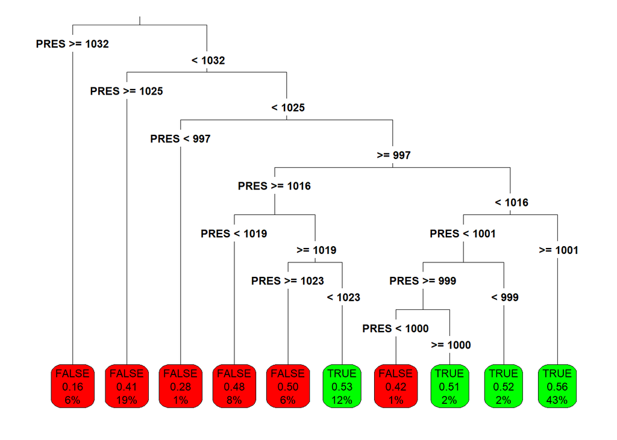

```r
PRSA_model <- rpart(bad_air ~ PRES, data = PRSA_train, method = 'class',
                    control = rpart.control(cp = 0))
rpart.plot(PRSA_model, type = 3, box.palette = c('red', 'green'),
           fallen.leaves = TRUE)
```

```r
PRSA_train$pred.PRES <- predict(PRSA_model, PRSA_train, type = 'class')
table(PRSA_train$bad_air, PRSA_train$pred.PRES)
```

```
##
##         FALSE  TRUE
##   FALSE  8421  8590
##   TRUE   5477 10608
```

```r
mean(PRSA_train$bad_air == PRSA_train$pred.PRES)
```

```
## [1] 0.5749637
```

다음으로는 PRES와 cbwd, Iws 변수를 이용해본다.

PRES 변수를 통해서 본 결과는 약 57%의 정확도를 보였다. 이 역시도 위에서 볼 수 있었듯, 박스 플랏 사이의 큰 차이가 없었으므로 단일 변수로써는 그 의미성이 떨어진다고 추측해볼 수 있다.

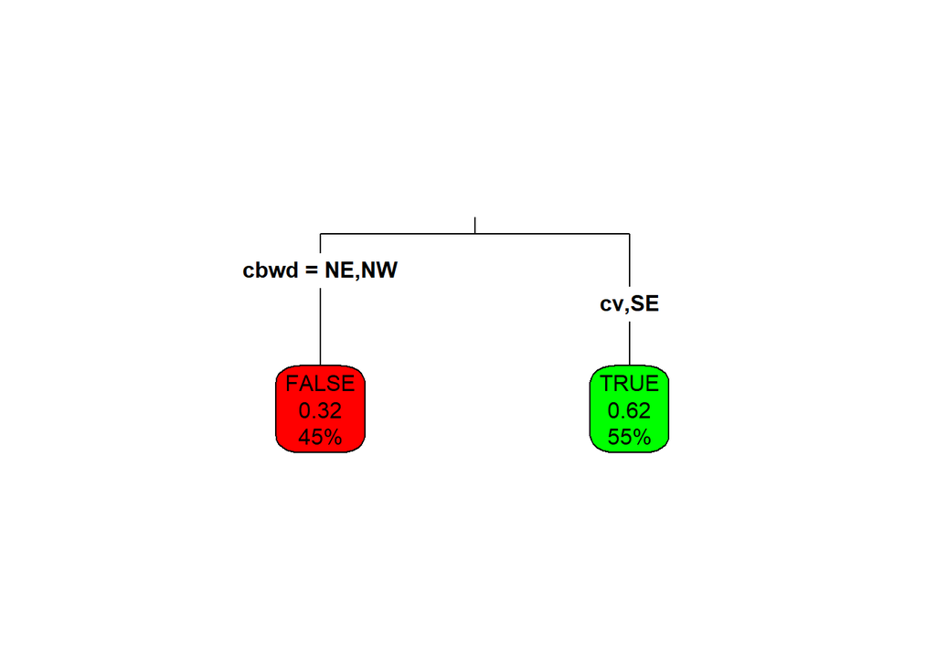

```r
PRSA_model <- rpart(bad_air ~ cbwd, data = PRSA_train, method = 'class',
                    control = rpart.control(cp = 0))
rpart.plot(PRSA_model, type = 3, box.palette = c('red', 'green'),
           fallen.leaves = TRUE)
```

```r
PRSA_train$pred.cbwd <- predict(PRSA_model, PRSA_train, type = 'class')
table(PRSA_train$bad_air, PRSA_train$pred.cbwd)
```

```
##
##         FALSE  TRUE
##   FALSE 10084  6927
##   TRUE   4737 11348
```

```r
mean(PRSA_train$bad_air == PRSA_train$pred.cbwd)
```

```
## [1] 0.6475707
```

[figure not shown]

```r
PRSA_model <- rpart(bad_air ~ Iws, data = PRSA_train, method = 'class',
                    control = rpart.control(cp = 0))
rpart.plot(PRSA_model, type = 3, box.palette = c('red', 'green'),
           fallen.leaves = TRUE)
```

```r
PRSA_train$pred.Iws <- predict(PRSA_model, PRSA_train, type = 'class')
table(PRSA_train$bad_air, PRSA_train$pred.Iws)
```

```
##
##         FALSE  TRUE
##   FALSE 11064  5947
##   TRUE   5156 10929
```

```r
mean(PRSA_train$bad_air == PRSA_train$pred.Iws)
```

```
## [1] 0.6645214
```

한편 cbwd와 Iws 변수는 단일 변수로써는 비교적 높은 수치인 약 65% 정도의 정확도를 보였다. 이는 북쪽에서 남쪽으로 불어오는 cv와 SE는 남쪽에서 북쪽으로 부는 NW와 NE 보다 더 높은 미세먼지 수치를 보였는데, 그 결과를 분석해보면 다음과 같은 결론을 얻을 수 있다. 주어진 이 데이터는 ‘베이징’ 지역의 미세먼지 수치를 기록한 데이터인데, 베이징의 지리적 특성상 베이징 보다 북쪽에 있는 몽골 지역 등에서 사막과 같은 영향으로 북에서 남으로 바람이 불때 미세먼지에 대한 피해가 더 심했다고 추측해볼 수 있겠다.

```r
PRSA_model <- rpart(bad_air ~ cbwd + Iws + PRES, data = PRSA_train, method = 'class',
                    control = rpart.control(cp = 0))
PRSA_train$pred.cbwd.Iws.PRES <- predict(PRSA_model, PRSA_train, type = 'class')
table(PRSA_train$bad_air, PRSA_train$pred.cbwd.Iws.PRES)
```

```
##
##         FALSE  TRUE
##   FALSE 11285  5726
##   TRUE   2995 13090
```

```r
mean(PRSA_train$bad_air == PRSA_train$pred.cbwd.Iws.PRES)
```

```
## [1] 0.7364938
```

그리고 바람의 방향, 풍속 그리고 기압까지 모두 고려한 결과에서는 보다 더 높은 약 74%의 결과를 얻은 것으로 보아 더 많은 변수들을 추가할수록 정확도 수치를 높일 수 있는 것을 볼 수 있다. 따라서 다음의 과정에서는 더 다양한 변수를 추가하여 예측도를 확인해보고자 한다.

# 더 많은 변수 이용

```r
PRSA_model <- rpart(bad_air ~ cbwd + Iws + PRES + TEMP + DEWP,
                    data = PRSA_train, method = 'class', control = rpart.control(cp = 0))
PRSA_train$pred.cbwd.Iws.PRES.TEMP.DEWP <- predict(PRSA_model, PRSA_train, type = 'class')
table(PRSA_train$bad_air, PRSA_train$pred.cbwd.Iws.PRES.TEMP.DEWP)
```

```
##
##         FALSE  TRUE
##   FALSE 13993  3018
##   TRUE   2528 13557
```

```r
mean(PRSA_train$bad_air == PRSA_train$pred.cbwd.Iws.PRES.TEMP.DEWP)
```

```
## [1] 0.8324269
```

```r
PRSA_model <- rpart(bad_air ~ cbwd + Iws + PRES + TEMP + DEWP + Ir + Is,
                    data = PRSA_train, method = 'class', control = rpart.control(cp = 0))
PRSA_train$pred <- predict(PRSA_model, PRSA_train, type = 'class')
conf.table <- table(PRSA_train$bad_air, PRSA_train$pred)
mean(PRSA_train$bad_air == PRSA_train$pred)
```

```
## [1] 0.8340585
```

지금까지의 과정을 통해 점점 더 많은 변수를 추가할수록 그 정확도 수치가 높았음을 확인할 수 있었다.

따라서 먼저 앞서 구했던 모델에서 TEMP와 DEWP 변수를 추가하니, 약 83.2%의 정확도가 나왔으며, 마지막으로는 주어진 모든 변수들을 통해 예측도를 구했더니 그보다 더 높아진 약 83.4%의 수치를 확인할 수 있었다.

# 가장 Accuracy가 높은 모델의 Precision, Recall, F1

```r
precision <- conf.table[2, 2] / sum(conf.table[, 2])
recall <- conf.table[2, 2] / sum(conf.table[2, ])
F1 <- (2 * precision * recall) / (precision + recall)

precision
```

```
## [1] 0.8183567
```

```r
recall
```

```
## [1] 0.8464408
```

```r
F1
```

```
## [1] 0.8321618
```

Accuracy가 가장 높았던 마지막 모델을 통해서 precision과 recall 그리고 F1 score를 구한다.

이를 통해 precision은 약 82%, recall은 약 85%, F1 score는 약 83%임을 확인할 수 있다.

## Q3

```r
PRSA_test$pred <- predict(PRSA_model, PRSA_test, type = 'class')
conf.table_test <-
  table(Actual = PRSA_test$bad_air, Pred = PRSA_test$pred)
mean(PRSA_test$bad_air == PRSA_test$pred)
```

```
## [1] 0.6857176
```

```r
precision_test <- conf.table_test[2, 2] / sum(conf.table_test[, 2])
recall_test <- conf.table_test[2, 2] / sum(conf.table_test[2, ])
F1_test <- (2 * precision_test * recall_test) /
  (precision_test + recall_test)

precision_test
```

```
## [1] 0.6672089
```

```r
recall_test
```

```
## [1] 0.6899784
```

```r
F1_test
```

```
## [1] 0.6784026
```

위에서 구했던 모델을 기반으로 test 데이터에도 적용시켰다.

그 결과, 기존에 train data에서는 80% 이상의 높은 성능이 나왔었는데, test data에서는 약 69% 정도로 train data 보다 낮은 수치를 보였다. 또한 precision과 recall, F1 score 모두에서 보다 낮은 수치를 보였다.

이를 통해 train data에서는 높은 예측도를 보였지만, test data에서는 그 성능이 떨어지는 결과를 확인할 수 있고, 이는 Overfitting이라고 표현할 수 있다. 결국 Decision Tree 방법의 특성상, 가지 수가 너무 많아지면 주어진 데이터에만 맞는 모델을 만들어내기 때문에 이는 과적합이 생기므로 당연한 결과가 나온 것으로 생각할 수 있다.

## Q4

```r
PRSA_model <- rpart(bad_air ~ cbwd + Iws + PRES + TEMP + DEWP + Ir + Is,
                    data = PRSA_train, method = 'class',
                    control = rpart.control(cp = 0, maxdepth = 15))
PRSA_train$pred_better <- predict(PRSA_model, PRSA_train, type = 'class')
PRSA_test$pred_better <- predict(PRSA_model, PRSA_test, type = 'class')
mean(PRSA_train$bad_air == PRSA_train$pred_better)
```

```
## [1] 0.8119108
```

```r
mean(PRSA_test$bad_air == PRSA_test$pred_better)
```

```
## [1] 0.6884886
```

과적합을 해소하기 위해서 Pre-Pruning 방법을 사용한다.

먼저는 maxdepth를 설정하여 train과 test data의 예측도가 과적합 되지 않도록 해본다.

위와 같은 시도를 통해서 확인할 수 있듯, 가장 먼저는 maxdepth을 15로 설정한 경우에는 기존과 거의 유사하게 train이 81%, test가 68%가 나와서 과적합인 결과를 확인할 수 있다.

```r
PRSA_model <- rpart(bad_air ~ cbwd + Iws + PRES + TEMP + DEWP + Ir + Is,
                    data = PRSA_train, method = 'class',
                    control = rpart.control(cp = 0, maxdepth = 10))
PRSA_train$pred_better <- predict(PRSA_model, PRSA_train, type = 'class')
PRSA_test$pred_better <- predict(PRSA_model, PRSA_test, type = 'class')
mean(PRSA_train$bad_air == PRSA_train$pred_better)
```

```
## [1] 0.7769217
```

```r
mean(PRSA_test$bad_air == PRSA_test$pred_better)
```

```
## [1] 0.693107
```

```r
PRSA_model <- rpart(bad_air ~ cbwd + Iws + PRES + TEMP + DEWP + Ir + Is,
                    data = PRSA_train, method = 'class',
                    control = rpart.control(cp = 0, maxdepth = 5))
PRSA_train$pred_better <- predict(PRSA_model, PRSA_train, type = 'class')
PRSA_test$pred_better <- predict(PRSA_model, PRSA_test, type = 'class')
mean(PRSA_train$bad_air == PRSA_train$pred_better)
```

```
## [1] 0.7322335
```

```r
mean(PRSA_test$bad_air == PRSA_test$pred_better)
```

```
## [1] 0.6663203
```

다시 maxdepth를 5로 줄이니 train이 73%, test가 66%가 나왔다.

```r
PRSA_model <- rpart(bad_air ~ cbwd + Iws + PRES + TEMP + DEWP + Ir + Is,
                    data = PRSA_train, method = 'class',
                    control = rpart.control(cp = 0, maxdepth = 4))
PRSA_train$pred_better <- predict(PRSA_model, PRSA_train, type = 'class')
PRSA_test$pred_better <- predict(PRSA_model, PRSA_test, type = 'class')
mean(PRSA_train$bad_air == PRSA_train$pred_better)
```

```
## [1] 0.7054931
```

```r
mean(PRSA_test$bad_air == PRSA_test$pred_better)
```

```
## [1] 0.6508486
```

다시 한번 값을 줄여서 maxdepth를 4로 하니 train이 70%, test가 65%가 나왔다.

```r
PRSA_model <- rpart(bad_air ~ cbwd + Iws + PRES + TEMP + DEWP + Ir + Is,
                    data = PRSA_train, method = 'class',
                    control = rpart.control(cp = 0, maxdepth = 3))
PRSA_train$pred_better <- predict(PRSA_model, PRSA_train, type = 'class')
PRSA_test$pred_better <- predict(PRSA_model, PRSA_test, type = 'class')
mean(PRSA_train$bad_air == PRSA_train$pred_better)
```

```
## [1] 0.6812908
```

```r
mean(PRSA_test$bad_air == PRSA_test$pred_better)
```

```
## [1] 0.6197899
```

마지막으로 값을 줄여서 maxdepth를 3으로 하면 train이 68%, test가 61%로 오히려 예측값이 감소하는 결과가 나온다.

## Q5

```r
PRSA_model <- rpart(bad_air ~ cbwd + Iws + PRES + TEMP + DEWP + Ir + Is,
                    data = PRSA_train, method = 'class', control = rpart.control(cp = 0))
printcp(PRSA_model)
```

```
##
## Classification tree:
## rpart(formula = bad_air ~ cbwd + Iws + PRES + TEMP + DEWP + Ir +
##     Is, data = PRSA_train, method = "class", control = rpart.control(cp = 0))
##
## Variables actually used in tree construction:
## [1] cbwd DEWP Ir   Is   Iws  PRES TEMP
##
## Root node error: 16085/33096 = 0.48601
##
## n= 33096
##
##            CP nsplit rel error  xerror      xstd
## 1  2.1212e-01      0   1.00000 1.00000 0.0056528
## 2  9.1016e-02      1   0.78788 0.78614 0.0054955
```

[output cut: 83 more lines]

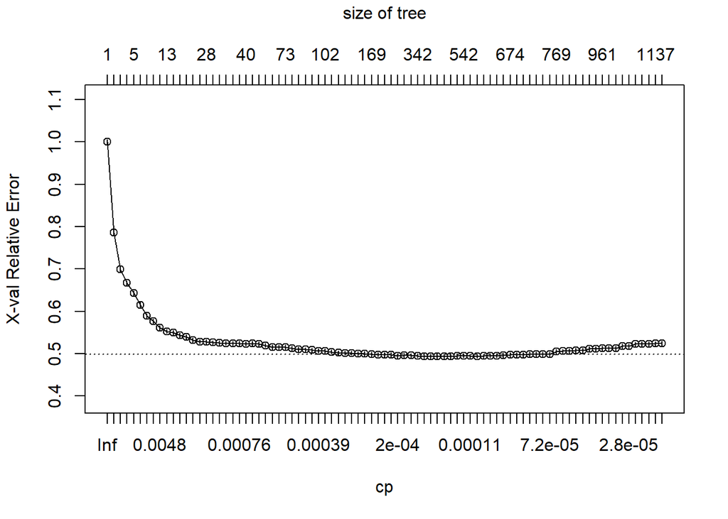

```r
plotcp(PRSA_model)
```

```r
ptree <- prune(PRSA_model,
               cp = PRSA_model$cptable[which.min(PRSA_model$cptable[, "xerror"]), "CP"])
PRSA_test$better_pred <- predict(ptree, PRSA_test, type = 'class')
PRSA_train$better_pred <- predict(ptree, PRSA_train, type = 'class')
mean(PRSA_test$bad_air == PRSA_test$better_pred)
```

```
## [1] 0.7017665
```

```r
mean(PRSA_train$bad_air == PRSA_train$better_pred)
```

```
## [1] 0.8038736
```

그런데 위의 방법을 통해 확인하면, 오히려 test data의 accuracy가 감소한 결과를 보였다. 따라서 과적합은 해결했지만, 그 예측도가 감소했으므로 다시 새롭게 과적합과 예측도 모두를 개선시키기 위한 방법을 고안했다.

동일하게 가지치기 방법을 통해 접근하려고 하는데, printcp 함수를 통해서 xerror가 가장 낮은 split 개수를 선택한다. 이를 위해서 cptable에서 “xerror” 열에서의 split의 최솟값을 which.min으로 읽어온다.

이를 통해 train과 test 데이터의 새로운 예측도를 구하면, train에서는 약 80%가, test에서는 약 70%가 나오고 전반적인 두 데이터의 격차를 줄였을 뿐 아니라, 기존의 test data의 예측도보다 약간 개선된 결과를 확인할 수 있다.

## Q6

```r
conf.table <-
  table(Actual = PRSA_test$bad_air, Pred = PRSA_test$better_pred)

precision <- conf.table[2, 2] / sum(conf.table[, 2])
recall <- conf.table[2, 2] / sum(conf.table[2, ])
precision
```

```
## [1] 0.6711497
```

```r
recall
```

```
## [1] 0.7435713
```

이 모델의 예측 결과를 통해 precision과 recall을 구하면 다음과 같다.

일반적으로 precision(False Positive)은 틀린 것을 맞다고 예측한 것이고, recall(False Negative)은 맞는 것을 틀리다고 예측한 것이다. 즉, precision은 미세먼지 농도가 심하지 않은데 심하다고 하는 것이고, recall은 미세먼지 농도가 심했는데 심하지 않았다고 예측한 것으로 평가할 수 있다.

따라서 미세먼지와 관련해서는 미세먼지 농도가 심했는데 심하지 않았다고 예측한 경우에서 더 많은 비용들이 지출될 가능성이 높다. 미세먼지 농도가 심하지 않은데 심하다고 예측한 것은 사람들이 더 조심하게 된 것 뿐이지만, recall 측면에서는 무방비 상태에서 미세먼지를 접해야 하기 때문이다.

따라서 미세먼지 농도가 심한데, 심하지 않다고 이야기하는 False Negative가 감소하여 궁극적으로 recall이 높아질수록 더 좋다.

## Q7

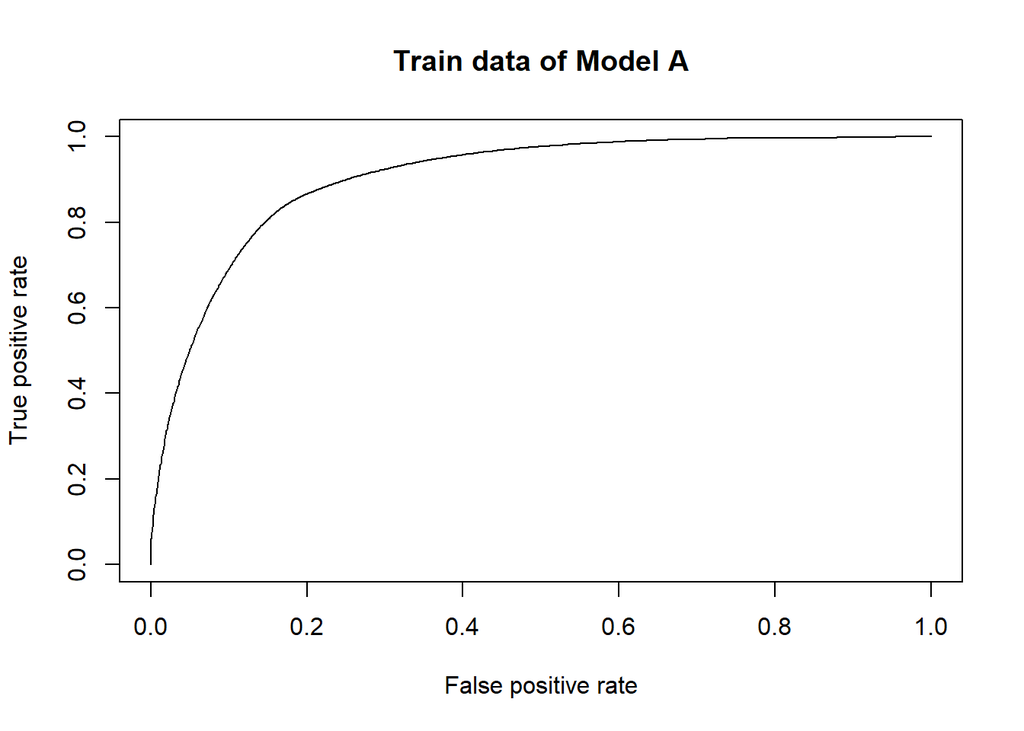

```r
calAUC <- function(predCol, targetCol){
  perf <- performance(prediction(predCol, targetCol), 'auc')
  as.numeric(perf@y.values)
}

Model_A <- rpart(bad_air ~ cbwd + Iws + PRES + TEMP + DEWP + Ir + Is,
                 data = PRSA_train, method = 'class', control = rpart.control(cp = 0))
PRSA_train$pred <- predict(Model_A, PRSA_train, type = 'prob')[, 2]
PRSA_test$pred <- predict(Model_A, PRSA_test, type = 'prob')[, 2]

plot(performance(prediction(PRSA_train$pred, PRSA_train$bad_air), 'tpr', 'fpr'), main = "Train data of Model A")
```

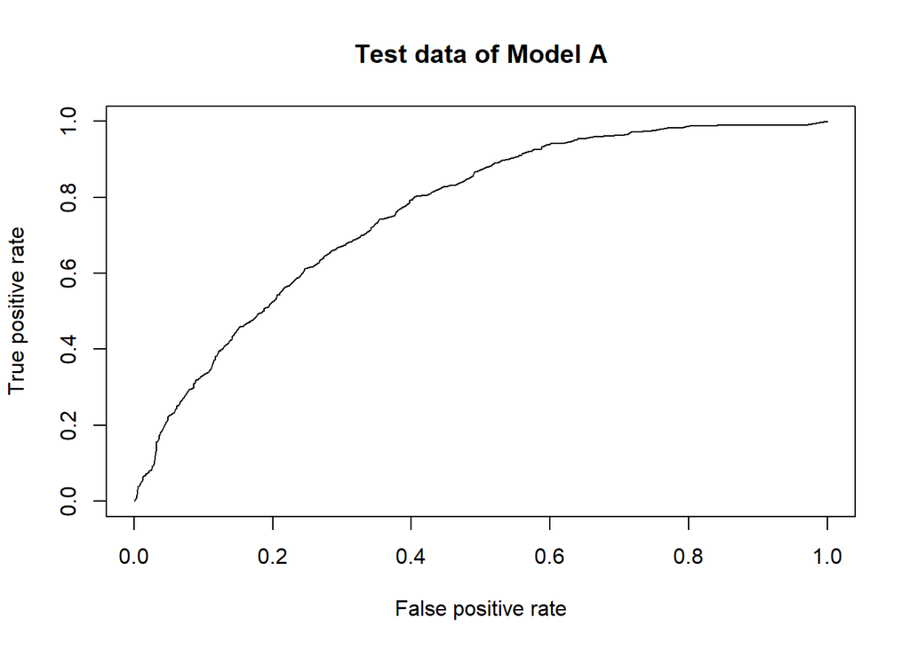

```r
plot(performance(prediction(PRSA_test$pred, PRSA_test$bad_air), 'tpr', 'fpr'), main = "Test data of Model A")
```

```r
calAUC(PRSA_train$pred, PRSA_train$bad_air)
```

```
## [1] 0.9046426
```

```r
calAUC(PRSA_test$pred, PRSA_test$bad_air)
```

```
## [1] 0.761971
```

모델 A와 B에 대하여 ROC 커브를 그리고, AUC를 계산한다.

먼저 모델 A의 경우에는 과적합이 비교적 더 심했던 모델인데, 실제로 ROC 커브와 AUC 결과를 보니 그 결과를 더욱 직관적으로 이해할 수 있었다. AUC 결과는 train에서는 90%를 보였지만, test에서는 76%로 많이 감소한 결과를 확인할 수 있다.

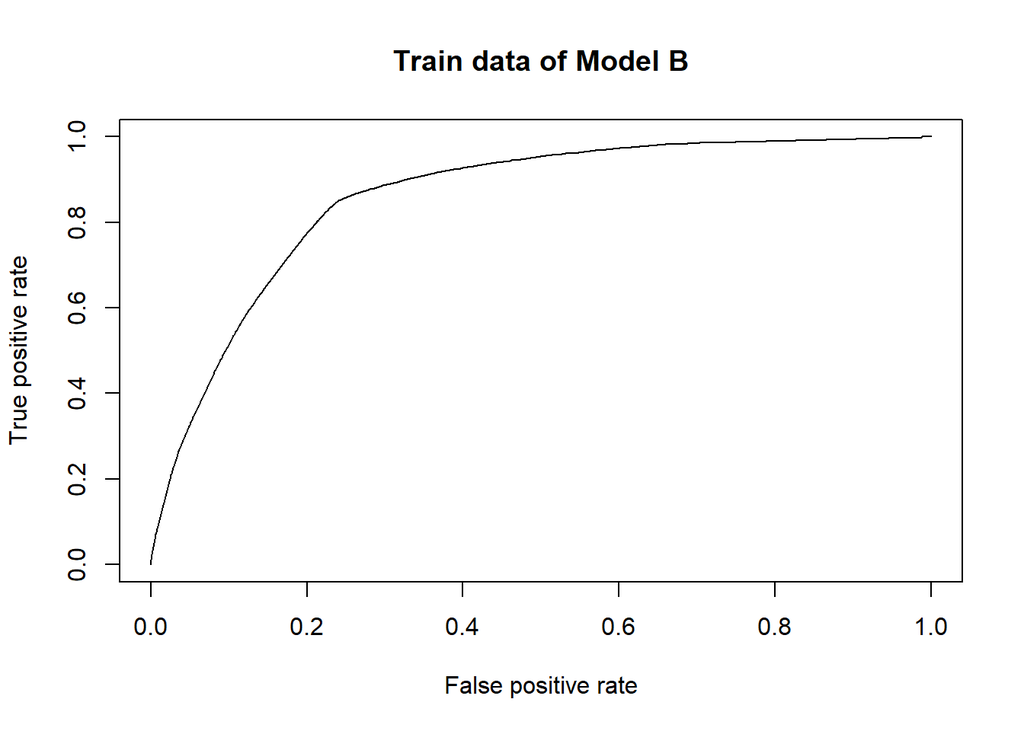

```r
Model_B <- ptree
PRSA_train$pred2 <- predict(ptree, PRSA_train, type = 'prob')[, 2]
PRSA_test$pred2 <- predict(ptree, PRSA_test, type = 'prob')[, 2]

plot(performance(prediction(PRSA_train$pred2, PRSA_train$bad_air), 'tpr', 'fpr'), main = "Train data of Model B")
```

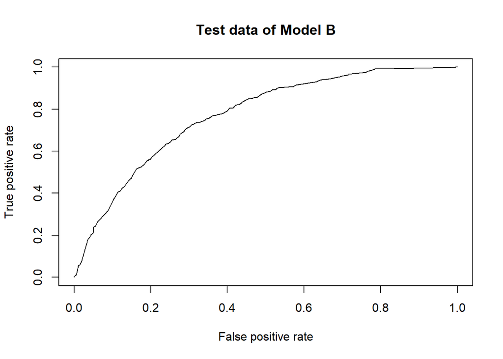

```r
plot(performance(prediction(PRSA_test$pred2, PRSA_test$bad_air), 'tpr', 'fpr'), main = "Test data of Model B")
```

```r
calAUC(PRSA_train$pred2, PRSA_train$bad_air)
```

```
## [1] 0.858623
```

```r
calAUC(PRSA_test$pred2, PRSA_test$bad_air)
```

```
## [1] 0.7726888
```

한편, 모델 B는 비교적 과적합을 줄였던 모델이다. 그렇기에 실제 ROC 커브와 AUC 결과로 이를 반영한 결과가 나왔다. train에서는 85%가 나왔고, test에서는 77% 정도의 AUC가 나왔다. 이 역시도 완벽히 과적합을 해결했다고 보기에는 어려울 수도 있겠지만, 그럼에도 모델 A 보다는 더 우위에 있다고 평가할 수 있겠다.

## Q8

```r
PRSA <- read.csv("PRSA_data.csv")
PRSA <- PRSA[-1]
PRSA <- na.omit(PRSA)

PRSA$bad_air <- ifelse(PRSA$pm2.5 > 75, TRUE, FALSE)
PRSA_dummy <- predict(dummyVars(~ cbwd, data = PRSA), PRSA)
PRSA <- cbind(PRSA, PRSA_dummy)

PRSA_train <- subset(PRSA, year < 2014)
PRSA_train_dummy <- PRSA_train[, 14:17]
PRSA_test <- subset(PRSA, year == 2014)
PRSA_test_dummy <- PRSA_test[, 14:17]

minmax_norm <- function(x){
  (x - min(x)) / (max(x) - min(x))
}
z_score <- function(x){
  (x - mean(x)) / var(x)
}
```

다음은 knn 방법으로 예측 모델을 만들어보려고 한다.

이 방법을 사용하기 위해서는 가장 먼저 전처리 단계가 필요하다. 그 이유는 처음에 기존 train data에서 summary를 한 것을 보게 되면, 각 변수들의 범위 폭이 다르다는 것을 쉽게 확인할 수 있다. 이 범위가 각각 다르다면, 유클리디 거리를 이용하는 것이 어렵기 때문에 적절한 판단을 위하여 scale을 비슷하게 맞춰주는 표준화가 필요하다.

또한 cbwd 변수는 factor형 변수이므로 Dummy coding(Ond hot encoding)을 통해서 각 변수별로 numeric 변수로 바꿔서 각각의 데이터에 넣는 작업들을 추가로 수행했다.

표준화를 위해서 두가지 방법을 사용했다.

```r
PRSA_train_minmax <- as.data.frame(lapply(PRSA_train[, c(6:8, 10:12)], minmax_norm))
PRSA_train_minmax <- cbind(PRSA_train_minmax, PRSA_train_dummy)
summary(PRSA_train_minmax)
```

```
##       DEWP             TEMP             PRES             Iws
##  Min.   :0.0000   Min.   :0.0000   Min.   :0.0000   Min.   :0.000000
##  1st Qu.:0.3607   1st Qu.:0.3333   1st Qu.:0.3091   1st Qu.:0.002371
##  Median :0.5574   Median :0.5333   Median :0.4545   Median :0.009486
##  Mean   :0.5683   Mean   :0.5177   Mean   :0.4618   Mean   :0.043481
##  3rd Qu.:0.7869   3rd Qu.:0.7000   3rd Qu.:0.6182   3rd Qu.:0.040369
##  Max.   :1.0000   Max.   :1.0000   Max.   :1.0000   Max.   :1.000000
##        Is                 Ir              cbwd.cv          cbwd.NE
##  Min.   :0.000000   Min.   :0.000000   Min.   :0.0000   Min.   :0.0000
##  1st Qu.:0.000000   1st Qu.:0.000000   1st Qu.:0.0000   1st Qu.:0.0000
##  Median :0.000000   Median :0.000000   Median :0.0000   Median :0.0000
##  Mean   :0.002254   Mean   :0.005866   Mean   :0.2081   Mean   :0.1137
##  3rd Qu.:0.000000   3rd Qu.:0.000000   3rd Qu.:0.0000   3rd Qu.:0.0000
##  Max.   :1.000000   Max.   :1.000000   Max.   :1.0000   Max.   :1.0000
##     cbwd.NW          cbwd.SE
##  Min.   :0.0000   Min.   :0.0000
##  1st Qu.:0.0000   1st Qu.:0.0000
##  Median :0.0000   Median :0.0000
##  Mean   :0.3341   Mean   :0.3441
##  3rd Qu.:1.0000   3rd Qu.:1.0000
##  Max.   :1.0000   Max.   :1.0000
```

```r
PRSA_test_minmax <- as.data.frame(lapply(PRSA_test[, c(6:8, 10:12)], minmax_norm))
PRSA_test_minmax <- cbind(PRSA_test_minmax, PRSA_test_dummy)
summary(PRSA_test_minmax)
```

```
##       DEWP             TEMP             PRES             Iws
##  Min.   :0.0000   Min.   :0.0000   Min.   :0.0000   Min.   :0.00000
##  1st Qu.:0.4769   1st Qu.:0.2909   1st Qu.:0.3261   1st Qu.:0.00304
##  Median :0.6769   Median :0.5091   Median :0.5000   Median :0.01010
##  Mean   :0.6473   Mean   :0.4856   Mean   :0.5133   Mean   :0.04315
##  3rd Qu.:0.8462   3rd Qu.:0.6545   3rd Qu.:0.6957   3rd Qu.:0.03755
##  Max.   :1.0000   Max.   :1.0000   Max.   :1.0000   Max.   :1.00000
##        Is                 Ir              cbwd.cv          cbwd.NE
##  Min.   :0.000000   Min.   :0.000000   Min.   :0.0000   Min.   :0.0000
##  1st Qu.:0.000000   1st Qu.:0.000000   1st Qu.:0.0000   1st Qu.:0.0000
##  Median :0.000000   Median :0.000000   Median :0.0000   Median :0.0000
##  Mean   :0.001491   Mean   :0.005763   Mean   :0.2374   Mean   :0.1147
##  3rd Qu.:0.000000   3rd Qu.:0.000000   3rd Qu.:0.0000   3rd Qu.:0.0000
##  Max.   :1.000000   Max.   :1.000000   Max.   :1.0000   Max.   :1.0000
##     cbwd.NW          cbwd.SE
##  Min.   :0.0000   Min.   :0.0000
##  1st Qu.:0.0000   1st Qu.:0.0000
##  Median :0.0000   Median :0.0000
##  Mean   :0.2801   Mean   :0.3679
##  3rd Qu.:1.0000   3rd Qu.:1.0000
##  Max.   :1.0000   Max.   :1.0000
```

첫째는, min-max 표준화 방법이다. 이는 최솟값과 최댓값을 기준으로 모든 값을 0에서 1 사이로 바꿔주는 것이다.

```r
PRSA_train_z <- as.data.frame(lapply(PRSA_train[, c(6:8, 10:12)], z_score))
PRSA_train_z <- cbind(PRSA_train_z, PRSA_train_dummy)
summary(PRSA_train_z)
```

```
##       DEWP                TEMP                PRES
##  Min.   :-0.164798   Min.   :-0.205479   Min.   :-0.233104
##  1st Qu.:-0.060212   1st Qu.:-0.073165   1st Qu.:-0.077078
##  Median :-0.003165   Median : 0.006223   Median :-0.003654
##  Mean   : 0.000000   Mean   : 0.000000   Mean   : 0.000000
##  3rd Qu.: 0.063390   3rd Qu.: 0.072380   3rd Qu.: 0.078948
##  Max.   : 0.125192   Max.   : 0.191463   Max.   : 0.271686
##       Iws                   Is                 Ir             cbwd.cv
##  Min.   :-0.0094606   Min.   :-0.09601   Min.   :-0.0936   Min.   :0.0000
##  1st Qu.:-0.0089446   1st Qu.:-0.09601   1st Qu.:-0.0936   1st Qu.:0.0000
##  Median :-0.0073966   Median :-0.09601   Median :-0.0936   Median :0.0000
##  Mean   : 0.0000000   Mean   : 0.00000   Mean   : 0.0000   Mean   :0.2081
##  3rd Qu.:-0.0006772   3rd Qu.:-0.09601   3rd Qu.:-0.0936   3rd Qu.:0.0000
##  Max.   : 0.2081195   Max.   :42.50452   Max.   :15.8632   Max.   :1.0000
##     cbwd.NE          cbwd.NW          cbwd.SE
##  Min.   :0.0000   Min.   :0.0000   Min.   :0.0000
##  1st Qu.:0.0000   1st Qu.:0.0000   1st Qu.:0.0000
##  Median :0.0000   Median :0.0000   Median :0.0000
##  Mean   :0.1137   Mean   :0.3341   Mean   :0.3441
##  3rd Qu.:0.0000   3rd Qu.:1.0000   3rd Qu.:1.0000
##  Max.   :1.0000   Max.   :1.0000   Max.   :1.0000
```

```r
PRSA_test_z <- as.data.frame(lapply(PRSA_test[, c(6:8, 10:12)], z_score))
PRSA_test_z <- cbind(PRSA_test_z, PRSA_test_dummy)
summary(PRSA_test_z)
```

```
##       DEWP                TEMP                PRES
##  Min.   :-0.209844   Min.   :-0.197937   Min.   :-0.248087
##  1st Qu.:-0.055228   1st Qu.:-0.079364   1st Qu.:-0.090498
##  Median : 0.009611   Median : 0.009566   Median :-0.006451
##  Mean   : 0.000000   Mean   : 0.000000   Mean   : 0.000000
##  3rd Qu.: 0.064474   3rd Qu.: 0.068853   3rd Qu.: 0.088103
##  Max.   : 0.114351   Max.   : 0.209659   Max.   : 0.235185
##       Iws                  Is                 Ir             cbwd.cv
##  Min.   :-0.009895   Min.   :-0.06826   Min.   :-0.1238   Min.   :0.0000
##  1st Qu.:-0.009198   1st Qu.:-0.06826   1st Qu.:-0.1238   1st Qu.:0.0000
##  Median :-0.007579   Median :-0.06826   Median :-0.1238   Median :0.0000
##  Mean   : 0.000000   Mean   : 0.00000   Mean   : 0.0000   Mean   :0.2374
##  3rd Qu.:-0.001283   3rd Qu.:-0.06826   3rd Qu.:-0.1238   3rd Qu.:0.0000
##  Max.   : 0.219449   Max.   :45.71167   Max.   :21.3585   Max.   :1.0000
##     cbwd.NE          cbwd.NW          cbwd.SE
##  Min.   :0.0000   Min.   :0.0000   Min.   :0.0000
##  1st Qu.:0.0000   1st Qu.:0.0000   1st Qu.:0.0000
##  Median :0.0000   Median :0.0000   Median :0.0000
##  Mean   :0.1147   Mean   :0.2801   Mean   :0.3679
##  3rd Qu.:0.0000   3rd Qu.:1.0000   3rd Qu.:1.0000
##  Max.   :1.0000   Max.   :1.0000   Max.   :1.0000
```

전처리한 이 변수들을 통해서 knn 방법을 통해 모델을 만들어보려고 한다.

## Q9

```r
sqrt(nrow(PRSA_train_minmax))
```

```
## [1] 181.9231
```

```r
PRSA_test_minmax_pred <- knn(train = PRSA_train_minmax, test = PRSA_test_minmax,
                             cl = PRSA_train$bad_air, k = 181)
mean(PRSA_test$bad_air == PRSA_test_minmax_pred)
```

```
## [1] 0.6770581
```

위에서 구했던 minmax를 통해 만든 변수와 z_score를 통해 만든 변수들로 knn 방법을 통해 예측도를 구해본다.

먼저는 행의 개수에 루트를 씌운 값을 기준으로 k를 설정하여 예측도를 비교해보았는데, minmax 방법은 약 67%가 나왔다.

```r
PRSA_test_z_pred <- knn(train = PRSA_train_z, test = PRSA_test_z,
                        cl = PRSA_train$bad_air, k = 181)
mean(PRSA_test$bad_air == PRSA_test_z_pred)
```

```
## [1] 0.7186237
```

```r
accuracy_knn <- mean(PRSA_test$bad_air == PRSA_test_z_pred)
cmat <- table(Actual = PRSA_test$bad_air, Pred = PRSA_test_z_pred)
precision_knn <- cmat[2, 2] / sum(cmat[, 2])
recall_knn <- cmat[2, 2] / sum(cmat[2, ])
F1_knn <- (2 * precision_knn * recall_knn) / (precision_knn + recall_knn)

accuracy_knn
```

```
## [1] 0.7186237
```

```r
precision_knn
```

```
## [1] 0.668821
```

```r
recall_knn
```

```
## [1] 0.8207162
```

```r
F1_knn
```

```
## [1] 0.7370238
```

그리고 z_score 방법은 약 71%가 나왔다. 그래서 더 높았던 z_score를 기준으로 precision과 recall, F1을 구했다.

이를 통해 accuracy는 71%, precision은 66%, recall은 82% 그리고 F1은 73%가 나왔다.

## Q10

```r
test_pred <- 0
k_pred <- as.data.frame(1:8661)
accuracy <- 0
precision <- 0
recall <- 0
F1 <- 0
AUC_by_k <- 0
k_data <- seq(10, 450, 20)

for(i in (1:23)){
  test_pred <- knn(train = PRSA_train_z, test = PRSA_test_z,
                   cl = PRSA_train$bad_air, k = k_data[i])
  k_pred[i] <- test_pred
  cmat <- table(Actual = PRSA_test$bad_air, Pred = test_pred)
  accuracy[i] <- mean(PRSA_test$bad_air == test_pred)
  precision[i] <- cmat[2, 2] / sum(cmat[, 2])
  recall[i] <- cmat[2, 2] / sum(cmat[2, ])
  F1[i] <- (2 * precision[i] * recall[i]) / (precision[i] + recall[i])
}

AUC <- as.data.frame(cbind(k_pred[1:23]))
colnames(AUC)[1] <- "V1"
AUC <- ifelse(AUC == TRUE, 1, 0)
AUC <- as.data.frame(AUC)
PRSA_test$bad_air <- ifelse(PRSA_test$bad_air == TRUE, 1, 0)

for(i in (1:23)){
  AUC_by_k[i] <- calAUC(AUC[, i], PRSA_test$bad_air)
}

k_df1 <- as.data.frame(cbind(k = k_data, accuracy = accuracy[1:23], precision = precision[1:23],
                            recall = recall[1:23], F1 = F1[1:23], AUC = AUC_by_k))
k_df1[order(k_df1$accuracy, decreasing = T), ]
```

```
##      k  accuracy precision    recall        F1       AUC
## 7  130 0.7234730 0.6756165 0.8163903 0.7393623 0.7269729
## 5   90 0.7228957 0.6777710 0.8067772 0.7366689 0.7260553
## 6  110 0.7228957 0.6763469 0.8115838 0.7378195 0.7262363
## 8  150 0.7225494 0.6733044 0.8207162 0.7397379 0.7262470
## 9  170 0.7207020 0.6709184 0.8216775 0.7386842 0.7245054
## 4   70 0.7201247 0.6770642 0.7981255 0.7326274 0.7230627
## 10 190 0.7193165 0.6690774 0.8226388 0.7379541 0.7232083
## 11 210 0.7182773 0.6675102 0.8240807 0.7375780 0.7222626
## 12 230 0.7181619 0.6666021 0.8269647 0.7381744 0.7222601
## 13 250 0.7175846 0.6656365 0.8281663 0.7380595 0.7217498
## 14 270 0.7166609 0.6649275 0.8269647 0.7371465 0.7208157
## 2   30 0.7153908 0.6772575 0.7786590 0.7244271 0.7177739
## 3   50 0.7153908 0.6743421 0.7882720 0.7268698 0.7181360
## 15 290 0.7152754 0.6637048 0.8257630 0.7359178 0.7194371
## 16 310 0.7129662 0.6614613 0.8245614 0.7340608 0.7171696
## 17 330 0.7118116 0.6609318 0.8216775 0.7325905 0.7159499
## 18 350 0.7112343 0.6596768 0.8240807 0.7327706 0.7154848
## 20 390 0.7108879 0.6587469 0.8262437 0.7330490 0.7152330
## 19 370 0.7106570 0.6588597 0.8248017 0.7325507 0.7149564
## 21 410 0.7089251 0.6568477 0.8252824 0.7314943 0.7133079
## 22 430 0.7063849 0.6538023 0.8264840 0.7300711 0.7109087
## 23 450 0.7049994 0.6520833 0.8274453 0.7293719 0.7096116
## 1   10 0.7007274 0.6695483 0.7445326 0.7050523 0.7023774
```

9번에서 사용한 k 값인 181 이외에 다른 값으로 전반적인 예측도를 확인해보려고 한다.

그래서 10부터 450까지 20씩 증가하는 값인 k_data를 기준으로 knn 모델의 예측도를 확인해본다. 또한 그에 따른 AUC도 하나의 Data frame으로 만들고, 궁극적으로는 k_df1이라는 새로운 데이터 프레임으로 k의 값에 따른 accuracy, precision, recall, F1, AUC를 넣었다.

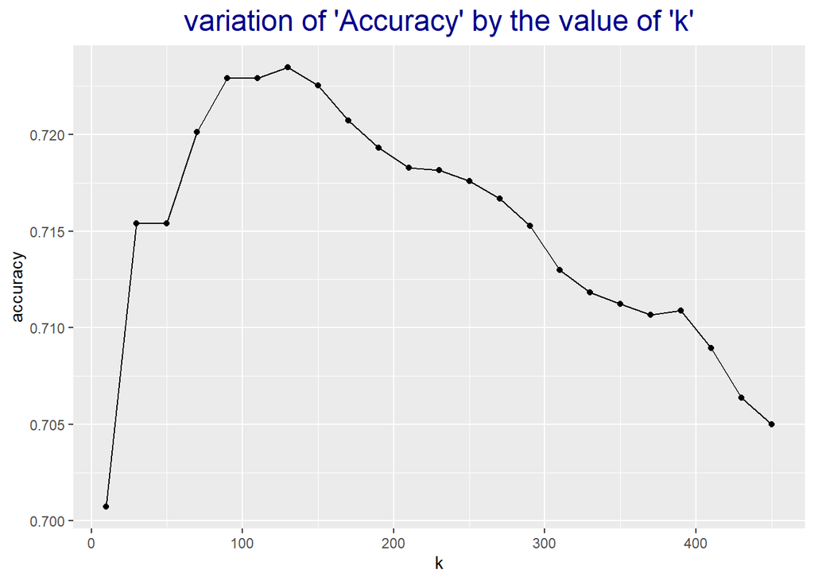

```r
ggplot(k_df1, aes(x = k, y = accuracy)) + geom_point() + geom_line() +
  ggtitle("variation of 'Accuracy' by the value of 'k'") +
  theme(plot.title = element_text(hjust = 0.5, size = 18, color = "darkblue"))
```

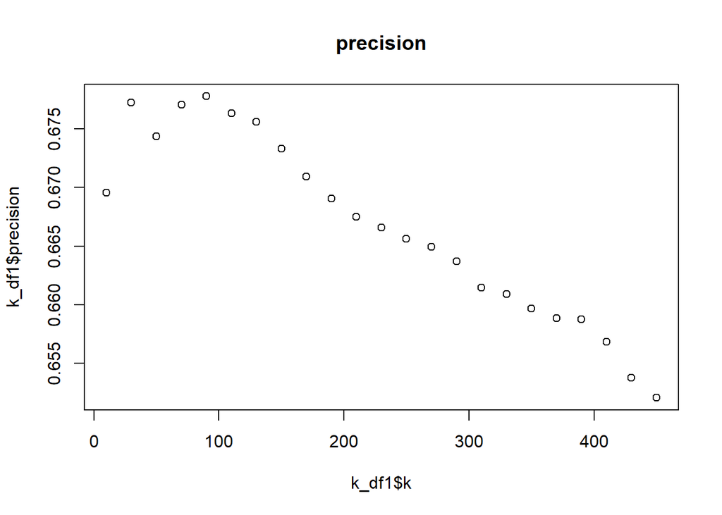

```r
plot(x = k_df1$k, y = k_df1$precision, main = "precision")
```

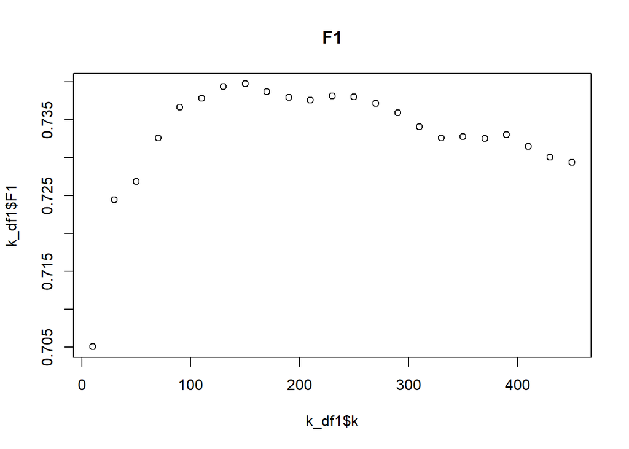

```r
plot(x = k_df1$k, y = k_df1$F1, main = "F1")
```

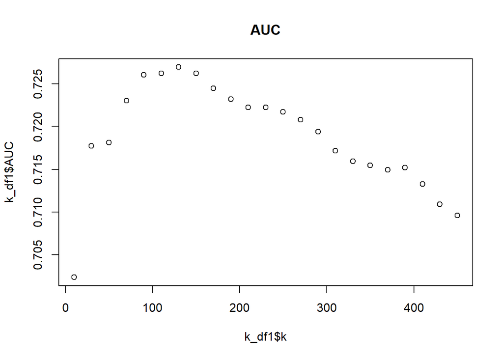

```r
plot(x = k_df1$k, y = k_df1$AUC, main = "AUC")
```

위 그래프는 k 값의 변화에 따라 달라지는 accuracy, precision, F1, AUC의 값을 그래프로 표현한 것이다.

## Q11

```r
k_df1[order(k_df1$recall, decreasing = T), ]
```

```
##      k  accuracy precision    recall        F1       AUC
## 13 250 0.7175846 0.6656365 0.8281663 0.7380595 0.7217498
## 23 450 0.7049994 0.6520833 0.8274453 0.7293719 0.7096116
## 12 230 0.7181619 0.6666021 0.8269647 0.7381744 0.7222601
## 14 270 0.7166609 0.6649275 0.8269647 0.7371465 0.7208157
## 22 430 0.7063849 0.6538023 0.8264840 0.7300711 0.7109087
## 20 390 0.7108879 0.6587469 0.8262437 0.7330490 0.7152330
## 15 290 0.7152754 0.6637048 0.8257630 0.7359178 0.7194371
## 21 410 0.7089251 0.6568477 0.8252824 0.7314943 0.7133079
## 19 370 0.7106570 0.6588597 0.8248017 0.7325507 0.7149564
## 16 310 0.7129662 0.6614613 0.8245614 0.7340608 0.7171696
## 11 210 0.7182773 0.6675102 0.8240807 0.7375780 0.7222626
## 18 350 0.7112343 0.6596768 0.8240807 0.7327706 0.7154848
## 10 190 0.7193165 0.6690774 0.8226388 0.7379541 0.7232083
## 9  170 0.7207020 0.6709184 0.8216775 0.7386842 0.7245054
## 17 330 0.7118116 0.6609318 0.8216775 0.7325905 0.7159499
## 8  150 0.7225494 0.6733044 0.8207162 0.7397379 0.7262470
## 7  130 0.7234730 0.6756165 0.8163903 0.7393623 0.7269729
## 6  110 0.7228957 0.6763469 0.8115838 0.7378195 0.7262363
## 5   90 0.7228957 0.6777710 0.8067772 0.7366689 0.7260553
## 4   70 0.7201247 0.6770642 0.7981255 0.7326274 0.7230627
## 3   50 0.7153908 0.6743421 0.7882720 0.7268698 0.7181360
## 2   30 0.7153908 0.6772575 0.7786590 0.7244271 0.7177739
## 1   10 0.7007274 0.6695483 0.7445326 0.7050523 0.7023774
```

6번에서 미세먼지 농도와 관련해서는 틀린 것을 맞다고 예측하는 precision보다 맞는 것을 틀리다고 예측한 recall이 더 중요하다고 이야기했었다. 그래서 결국 False Negative가 감소하여 recall이 높아질수록 좋다.

따라서 더 중요하다고 할 수 있는 지표인 recall을 높이기 위해서 k 값의 변화에 따라서 recall의 변화를 볼 수 있을 것이라고 생각했다.

이를 위해서 10번 문제에서 만들었던 k 값에 따른 accuracy, precision, recall, F1, AUC 값의 변화를 보여주는 데이터 프레임에서 recall 값이 최대가 되는 값을 찾았다.

이 결과 속에서 보니 k가 250일 때, recall이 약 83% 정도로 가장 높았음을 확인할 수 있었다.

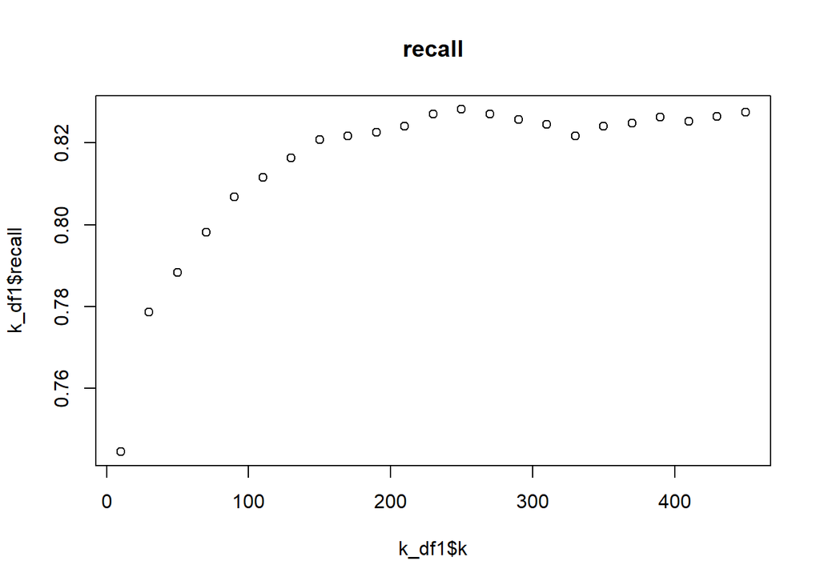

```r
plot(x = k_df1$k, y = k_df1$recall, main = "recall")
```

그런데 recall 값에 대하여 plot 그래프를 그려보니, 전반적으로 k의 값이 증가할수록 recall 값도 증가하고 있음을 볼 수 있었다. 그래서 다시 한번 k 값을 조금 더 늘려서 그에 따른 accuracy, precision, recall, F1을 보고자 했다.

```r
test_pred <- 0
accuracy <- 0
precision <- 0
recall <- 0
F1 <- 0
k_data <- 480:499
PRSA_test$bad_air <- ifelse(PRSA_test$bad_air == 1, TRUE, FALSE)

for(i in (1:20)){
  test_pred <- knn(train = PRSA_train_z, test = PRSA_test_z,
                   cl = PRSA_train$bad_air, k = k_data[i])
  cmat <- table(Actual = PRSA_test$bad_air, Pred = test_pred)
  accuracy[i] <- mean(PRSA_test$bad_air == test_pred)
  precision[i] <- cmat[2, 2] / sum(cmat[, 2])
  recall[i] <- cmat[2, 2] / sum(cmat[2, ])
  F1[i] <- (2 * precision[i] * recall[i]) / (precision[i] + recall[i])
}

k_df <- as.data.frame(cbind(k = k_data, accuracy = accuracy[1:20], precision = precision[1:20],
                            recall = recall[1:20], F1 = F1[1:20]))
k_df <- rbind(k_df, k_df1[, 1:5])
k_df[order(k_df$recall, decreasing = T), ]
```

```
##      k  accuracy precision    recall        F1
## 17 496 0.7018820 0.6483744 0.8291276 0.7276946
## 16 495 0.7021129 0.6486741 0.8288873 0.7277907
## 10 489 0.7026902 0.6493409 0.8286470 0.7281174
## 13 492 0.7028057 0.6494632 0.8286470 0.7281943
## 15 494 0.7017665 0.6483640 0.8286470 0.7275029
## 18 497 0.7018820 0.6484860 0.8286470 0.7275797
## 4  483 0.7025748 0.6492748 0.8284066 0.7279831
## 6  485 0.7026902 0.6493971 0.8284066 0.7280600
## 11 490 0.7025748 0.6492748 0.8284066 0.7279831
## 19 498 0.7017665 0.6484199 0.8284066 0.7274454
## 20 499 0.7017665 0.6484199 0.8284066 0.7274454
## 2  481 0.7022284 0.6489642 0.8281663 0.7276951
## 7  486 0.7024593 0.6492087 0.8281663 0.7278488
## 8  487 0.7025748 0.6493311 0.8281663 0.7279256
```

[output cut: 29 more lines]

k의 값은 480부터 499까지 했고, 500 이상인 경우에는 오류가 나지 못해서 최댓값을 499로 설정했다.

이를 통해서 구했던 값들을 하나의 데이터 프레임에 넣어서 확인해보면 위와 같다. 또한 10번에서 구했던 k 값들에 따른 accuracy, precision, recall, F1 값들의 데이터 프레임과 rbind로 묶어서 order 함수를 통해 이 데이터 프레임에서 가장 recall이 큰 값을 발견할 수 있었다. 그리고 그 수치는 약 83% 정도 되었는데, 마지막으로 threshold를 조정하여 이 recall 값을 더욱 끌어 올려보려는 시도를 해보고자 한다.

```r
PRSA_test_pred <- knn(train = PRSA_train_z, test = PRSA_test_z, cl = PRSA_train$bad_air,
                      k = 496, prob = TRUE)
head(PRSA_test_pred)
```

```
## [1] FALSE FALSE FALSE FALSE TRUE  FALSE
## Levels: FALSE TRUE
```

```r
head(attributes(PRSA_test_pred)$prob)
```

```
## [1] 0.9758065 0.9556452 0.9516129 0.9496982 0.7665996 0.6189516
```

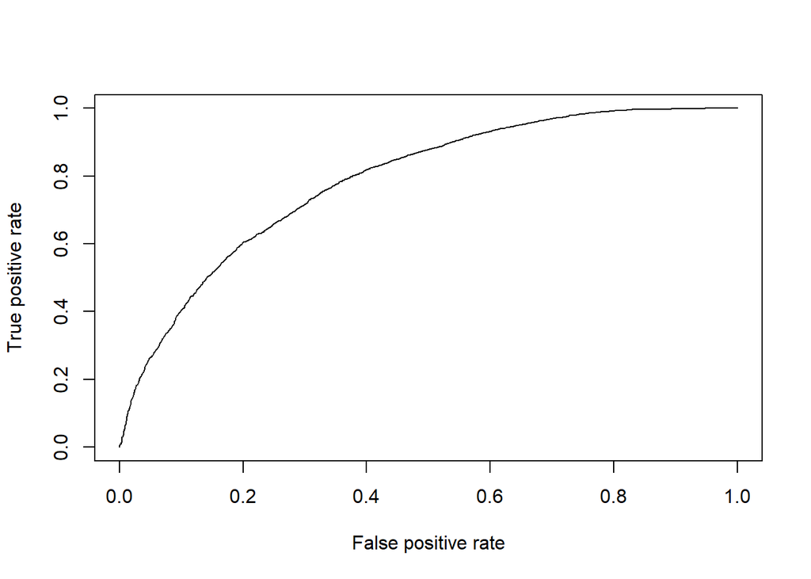

```r
PRSA_test_pred_prob <- ifelse(PRSA_test_pred == TRUE,
                              attributes(PRSA_test_pred)$prob,
                              1 - attributes(PRSA_test_pred)$prob)
plot(performance(prediction(PRSA_test_pred_prob, PRSA_test$bad_air == TRUE), 'tpr', 'fpr'))
```

```r
calAUC(PRSA_test_pred_prob, PRSA_test$bad_air == TRUE)
```

```
## [1] 0.7871923
```

가장 먼저는 위의 과정에서 recall을 최대로 만들었던 k = 496으로 probabilisitc interpretaion을 진행해보려고 한다.

미세먼지 농도가 심한지 여부에 따라 확률값을 표현하고, 그 농도가 심할 때의 확률을 표현했다.

```r
threshold <- 0.3
PRSA_test_pred_new <- ifelse(PRSA_test_pred_prob > threshold, TRUE, FALSE)
cmat <- table(Actual = PRSA_test$bad_air, Pred = PRSA_test_pred_new)
new_precision <- cmat[2, 2] / sum(cmat[, 2])
new_recall <- cmat[2, 2] / sum(cmat[2, ])
new_precision
```

```
## [1] 0.5635243
```

```r
new_recall
```

```
## [1] 0.9668349
```

가장 먼저는 threshold를 0.3으로 설정하여 실제 값과 예측 값들의 분포와 그에 따른 precision, recall 값을 계산했다.

이 과정에서 계산해보니 precision은 56% 정도가 나왔고, recall은 96%가 나왔다.

```r
threshold <- 0.2
PRSA_test_pred_new <- ifelse(PRSA_test_pred_prob > threshold, TRUE, FALSE)
cmat <- table(Actual = PRSA_test$bad_air, Pred = PRSA_test_pred_new)
new_precision <- cmat[2, 2] / sum(cmat[, 2])
new_recall <- cmat[2, 2] / sum(cmat[2, ])
new_precision
```

```
## [1] 0.5464977
```

```r
new_recall
```

```
## [1] 0.9843788
```

혹시 조금 더 올릴 수 있는지 확인하기 위하여 threshold를 0.2까지 낮춰서 다시 계산해본다.

이를 통해 조금 더 recall이 개선된 98%를 얻을 수 있었다.

```r
threshold <- 0.1
PRSA_test_pred_new <- ifelse(PRSA_test_pred_prob > threshold, TRUE, FALSE)
cmat <- table(Actual = PRSA_test$bad_air, Pred = PRSA_test_pred_new)
new_precision <- cmat[2, 2] / sum(cmat[, 2])
new_recall <- cmat[2, 2] / sum(cmat[2, ])
new_precision
```

```
## [1] 0.5262757
```

```r
new_recall
```

```
## [1] 0.9963951
```

```r
cmat
```

```
##        Pred
## Actual  FALSE TRUE
##   FALSE   768 3732
##   TRUE     15 4146
```

마지막으로 threshold를 0.1로 설정해서 다시 구해본다.

이를 통해서 recall 값이 99%까지 올릴 수 있었고, precision은 52%로 나오는 것을 확인 할 수 있었다.

recall의 값은 많이 올렸지만, recall과 precision의 적정한 기준에 대해서는 더욱 고민해볼 필요가 있을 것으로 생각된다.